# scRNASeq Barcode data

Wenjie Sun

2023-09-05 15:52:33

```r
library(data.table)
library(ggplot2)
library(CellBarcode)

knitr::opts_chunk$set(
    fig.width = 6,
    fig.height = 4
)
```

# Introduction

The lineage barcode is a sequence used for labeling cells. The labeling is usually done by adding the lineage barcode sequence to DNA. The sequence can be transcripted and thus detected by scRNASeq.

This vignette is a tutorial for how to extract lineage barcodes from scRNASeq data and do the cleaning of them.

This process can use `fastq` file or `bam` file as input.

The `fastq` file contains the reads without alignment information. The CellBarcode can search barcode in fastq file as well as cell barcode and UMI sequences by giving the reads structure. The read structure tells CellBarcode where to find the barcode sequence, cell barcode and UMI sequences. The barcode sequence can be low expressed. To incrase detected the barcode reads, the target amplification can be carried out. The target amplification is a PCR process, which use the barcode spacific primer to amplifing the barcode sequence after cell barcode tagging. The targeted amplifed and normal scRNASeq data both can be used as input of CellBarcode.

The `bam` file contains the reads with alignment information, in which the cell barcode and UMI sequences have been digested. The CellBarcode can search barcode in bam file with regular expression, at the same time extract the cell barcodes and UMI sequences. In order to find the cell barcode and UMI sequences in `bam` file, the tag of the two sequences need to be specified. In most case, in the bam file, the barcode sequence is not aligned to the reference genome as they are not part of the genome, thus we can do a quick filtering to get the un-mapped reads to reduce the running time of barcode searching.

# Extract barcodes from fastq file

## Extract lineage barcode

Here we use the targeted amplified fastq file as example. The fastq files are derived from [Cosgrove et al. 2023](https://www.biorxiv.org/content/10.1101/2023.01.24.525166v1), it can be aquiared from the author by email.

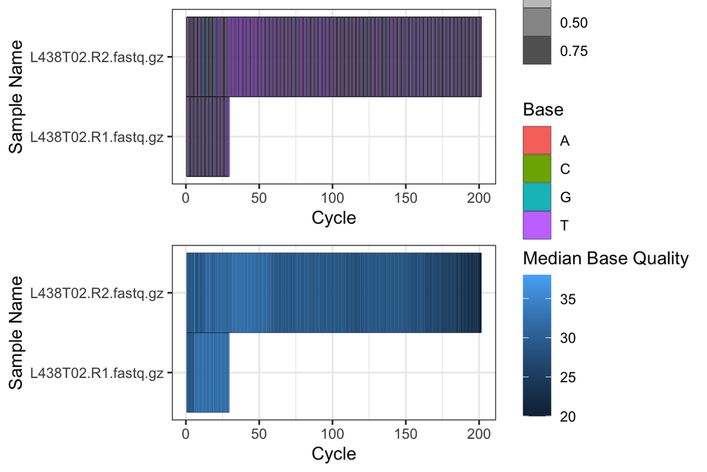

```r
s1_file <- c(
    "../run_scRNASeq_example_cosgrove/data/KDI_2015730_2023-01-31_14-58-15/L438T02/L438T02.R1.fastq.gz",
    "../run_scRNASeq_example_cosgrove/data/KDI_2015730_2023-01-31_14-58-15/L438T02/L438T02.R2.fastq.gz")

bc_qc <- bc_seq_qc(s1_file)

bc_plot_seqQc(bc_qc)
```

It is a paired-end fastq file. The read one is 28bp, which contains the cellular barcode (16bp) and UMI (12bp).

We use `(.{16)` to define the 16bp cellular barocde pattern. And `.{16}(.{12})` is used to define the UMI pattern. The `.` means any character, and the number after it `{16}` means the repeats of that character. The `()` used to define the sequence we are intreasted, the the sequence outside it serves as context for defining the target.

Then, the read 2 contains the lineage barcode, which can be identified by the pattern `CGAAGTATCAAG(.+)CCGTAGCAAG`.

```r
bc_obj1 = bc_extract_sc_fastq(
    fq1 = s1_file[1],                               ## fastq file 1
    fq2 = s1_file[2],                               ## fastq file 2
    patternCellBarcode = "(.{16})",                 ## Cell barcode pattern
    patternUMI = ".{16}(.{12})",                    ## UMI pattern
    patternBarcode = "CGAAGTATCAAG(.+)CCGTAGCAAG"   ## Lineage barcode pattern
)
```

## Check the quality of extracted barcodes

The `bc_plot_count` will tell you some numbers of extracted barcodes:

1. reads count (with barcode) versus the total reads
2. reads count per UMI
3. UMI count per barcode
4. barcode count per sample

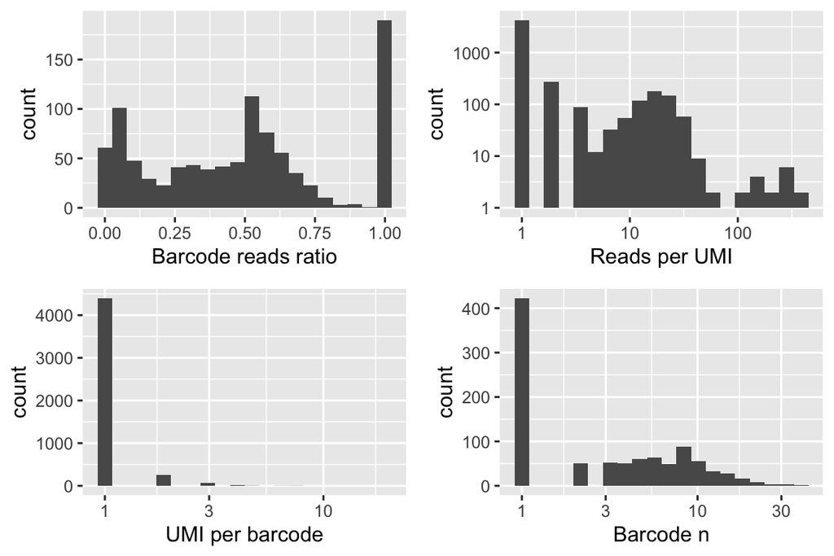

```r
bc_plot_count(bc_obj1, useClean=F)
```

## Filter barcode

Firstly we filter the barcode by UMI reads count. It is the number of reads with the same UMI-barcode sequence. The higher UMI reads count means the higher confidence of the barcode sequence.

From previous barcode number distribution, we can find a UMI can link to multiple barcodes. When the UMI diversity is high, each UMI should link to only one barcode sequence. Therefore, the `isUniqueUMI` parameter should be set on. And the most frequent barcode is kept for each UMI.

```r
## Count the UMI with at least 3 reads
bc_obj = bc_cure_umi(bc_obj1, depth = 3, isUniqueUMI = T)
```

Then we filter the barcode by the UMI count. The UMI count is the number of UMI a barcode sequence has.

```r
## Keep the barcodes with at least 2 UMIs
bc_obj = bc_cure_depth(bc_obj, depth = 2)
```

Then we can export the barcode sequence to a R data object such as `data.frame`, `data.table` or `data.matrix` for further analysis.

```r
## export data.frame
d <- bc_2df(bc_obj)
head(d)
```

```
#>        sample_name                  barcode_seq count
#> 1 AAAGTCCAGAACCGCA TCCAGATCTACTATCGTTACGGCTACTA     3
#> 2 AACAAAGTCTTCTGGC     TCCAGTATCGTTACGACGCTACTA     3
#> 3 AACCATGAGCTCTTCC    TCCAGTCGTTACGACGTAGCTACTA     3
#> 4 AAGTACCCATAATGCC     TCCAGTATCGTTACGACGCTACTA     3
#> 5 AATTCCTTCTATTGTC     TCCAGTATCGTTACGACGCTACTA     2
#> 6 AATTTCCTCACGATAC     TCCCTTATCGTTACGACGCTACTA     2
```

```r
## export data.table
d <- bc_2df(bc_obj)
head(d)
```

```
#>        sample_name                  barcode_seq count
#> 1 AAAGTCCAGAACCGCA TCCAGATCTACTATCGTTACGGCTACTA     3
#> 2 AACAAAGTCTTCTGGC     TCCAGTATCGTTACGACGCTACTA     3
#> 3 AACCATGAGCTCTTCC    TCCAGTCGTTACGACGTAGCTACTA     3
#> 4 AAGTACCCATAATGCC     TCCAGTATCGTTACGACGCTACTA     3
#> 5 AATTCCTTCTATTGTC     TCCAGTATCGTTACGACGCTACTA     2
#> 6 AATTTCCTCACGATAC     TCCCTTATCGTTACGACGCTACTA     2
```

```r
## export data.matrix
d <- bc_2matrix(bc_obj)
d[1:5, 1:3]
```

```
#>                               AAAGTCCAGAACCGCA AACAAAGTCTTCTGGC AACCATGAGCTCTTCC
#> TCCAATTACTATCGTTACGGTAGCTACTA                0                0                0
#> TCCACTACTATCGTTACGTACTA                      0                0                0
#> TCCACTATCGTTACGACGCTACTA                     0                0                0
#> TCCACTATCGTTACGACGTAGCTACTA                  0                0                0
#> TCCACTATCGTTACGACTACTA                       0                0                0
```

## Explore the threshold

We can explore the effect of the UMI read count threshold and UMI count threadhold we used above, by trying a range of values.

### UMI read count threshold

From the result, we can find the UMI read count threshold of 2 can keep most the UMI with unique barcode. And the far strigent threshold benifit little and may cause the loss of some barcodes.

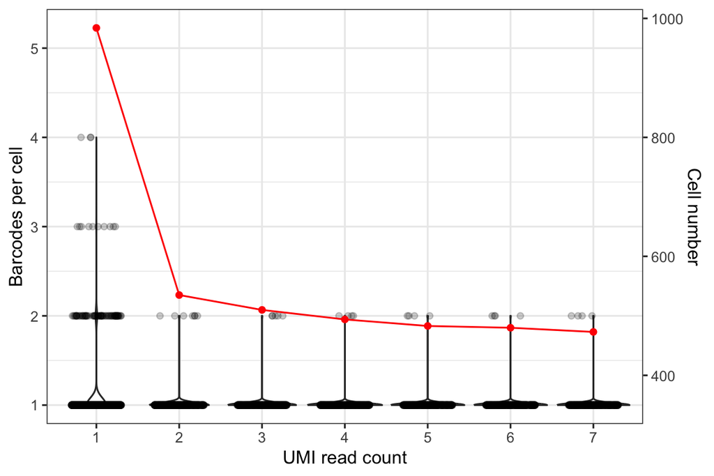

```r
## try the UMI read count threshold from 1 to 7
d_plot = lapply(1:7, function(i) {
    bc_obj = bc_cure_umi(bc_obj1, depth = i, isUniqueUMI = T)
    d = bc_2dt(bc_obj)
    d = d[, .(barcode_seq = unique(barcode_seq)), by = sample_name][, .N, by = sample_name]
    d$filter = i
    d
})
d_plot <- rbindlist(d_plot)

d_plot_plus = d_plot[, .N, by = filter]
## scale the left and right y-axis
a = 200
b = 150

## plot the result
ggplot(d_plot) + aes(x = factor(filter), y = N) +
    geom_violin() +
    geom_point(position = position_jitter(w = 0.3, h = 0), alpha = 0.2) +
    geom_line(data = d_plot_plus, aes(x = filter, y = (N - a) / b), color = "red") +
    geom_point(data = d_plot_plus, aes(x = filter, y = (N - a) / b), color = "red") +
    scale_y_continuous(
        name = 'Barcodes per cell',
        sec.axis = sec_axis(~ (. * b + a),name = "Cell number")) +
    labs(x = "UMI read count") + theme_bw()
```

### UMI count threshold

By fixing the UMI read count threshold to 2, we can explore the effect of the UMI count threshold.

Similarity, we can find the UMI count threshold of 2 can make sure most of the cells have unique barcode. And the far strigent threshold benifit little and may cause the loss of some barcodes.

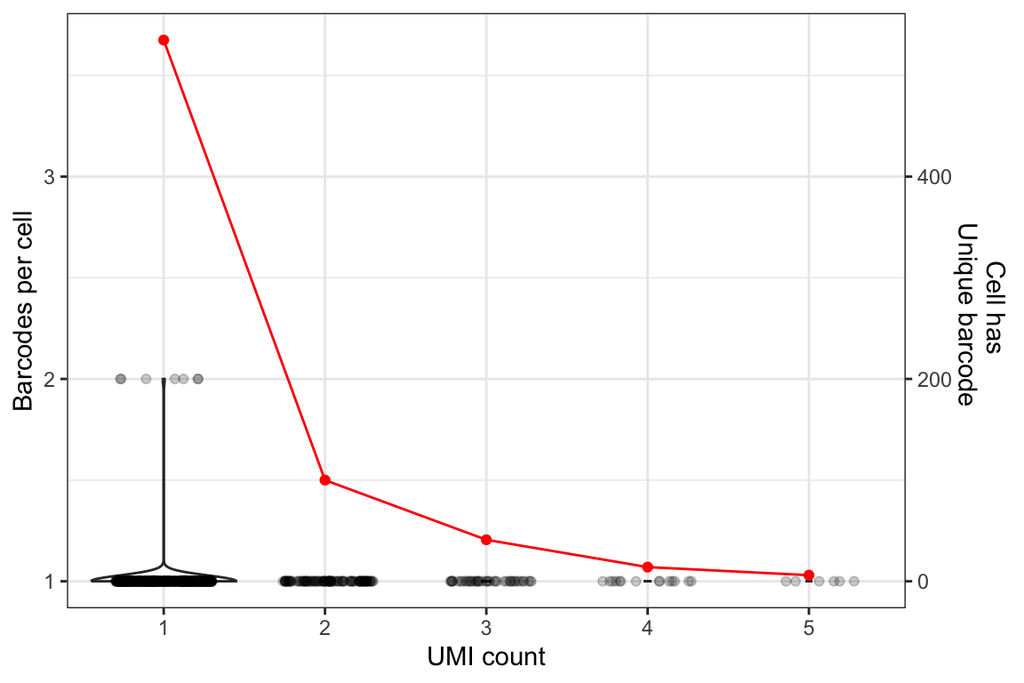

```r
## fix the UMI read count threshold to 2
bc_obj = bc_cure_umi(bc_obj1, depth = 2, isUniqueUMI = T)

## try the UMI count threshold from 1 to 5
d_plot = lapply(1:5, function(i) {
    bc_obj = bc_cure_depth(bc_obj, depth = i)
    d = bc_2dt(bc_obj)
    d = d[, .(barcode_seq = unique(barcode_seq)), by = sample_name][, .N, by = sample_name]
    d$filter = i
    d
})

d_plot <- rbindlist(d_plot)

d_plot_plus = d_plot[N == 1, .N, by = filter]
d_plot_plus = d_plot[, .N, by = filter]
## scale the left and right y-axis
a = -200
b = 200

## plot the result
ggplot(d_plot) + aes(x = factor(filter), y = N) +
    geom_violin() +
    geom_point(position = position_jitter(w = 0.3, h = 0), alpha = 0.2) +
    geom_line(data = d_plot_plus, aes(x = filter, y = ((N - a) / b)), color = "red") +
    geom_point(data = d_plot_plus, aes(x = filter, y = ((N - a) / b)), color = "red") +
    scale_y_continuous(
        name = 'Barcodes per cell',
        sec.axis = sec_axis(~ (. * b + a),
        name = "Cell has \n Unique barcode")) +
    labs(x = "UMI count") + theme_bw()
```